# 70-467 Machine Learning for Business Analytics

Logistic regression

Professor: Andrés Castaño Zuluaga

CMU-Q

## Can we predict which juice a shopper buys?

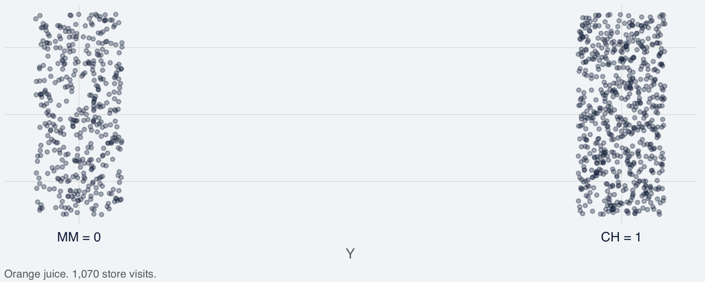

The dataset has 1,070 store visits. Each one ends in Citrus Hill or Minute Maid.

## Where are we on the course roadmap?

| Topic | Description | Tools |
| --- | --- | --- |
| Predict & evaluate |  |  |
| Linear regression | Predict a number | OLS |
| Metrics | Size of the errors | RMSE, R² |
| Train/test, leakage, cross-validation | Error on new data | Holdout, k-fold |
| Selection + regularization | Select variables or shrink coefficients | Best subset, ridge, lasso |
| Classify & decide |  |  |
| Logistic | Probability of a brand | Logistic regression |
| Thresholds | Turn a probability into a predicted brand | ROC, cutoff |
| Flexible & unsupervised |  |  |
| Trees | Split the predictors in sequence | Decision trees |
| Forests / boosting | Combine many trees | Random forest, boosting |
| PCA | Fewer combinations of the predictors | Principal components |
| Clustering | Group similar observations | K-means |

Before we have dealt with problems where the outcome was a continuous variable, like predicting a credit card balance, the price of a house, etc, and how do we decide which predictors to keep.

This week the outcome is the brand on the visit, Citrus Hill or Minute Maid. We want the probability the visit bought Citrus Hill.

## What we will do

1. The linear probability model: least squares of a 0/1 outcome
2. Logistic regression: a model for the p(Y = 1 | X)
3. Making sense of the coefficients in logistic regression: the log-odds, the odds, and the changes in the probabilities
4. Estimating the probabilities for a given visit
5. Assessing the Classification accuracy — make-up

## How is the brand coded?

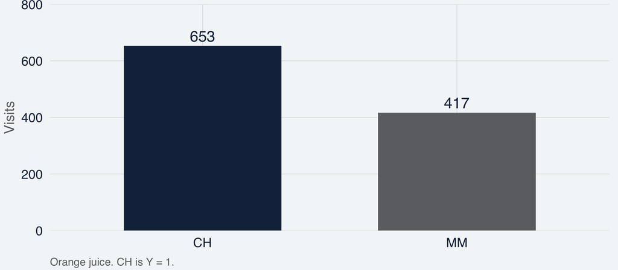

653 of 1,070 visits bought CH, 61 percent. The other 417 bought MM. CH is Y = 1.

## Codebook for the dataset?

| Variable | Type | Unit | Description |
| --- | --- | --- | --- |
| Purchase | text | CH or MM | Brand bought on the visit. This is the outcome. We code Y = 1 for CH and Y = 0 for MM. |
| LoyalCH | numeric | score, 0 to 1 | Loyalty to CH, already in the dataset. Used in the prediction. |
| SalePriceMM | numeric | dollars | Shelf price of MM. Used only to build PriceDiff. |
| SalePriceCH | numeric | dollars | Shelf price of CH. Used only to build PriceDiff. |
| PriceDiff | numeric | dollars | SalePriceMM minus SalePriceCH. Positive when MM costs more. Used in the prediction. |

Two variables enter the prediction: LoyalCH, and PriceDiff, which is the MM price minus the CH price.

## Does loyalty separate the two brands?

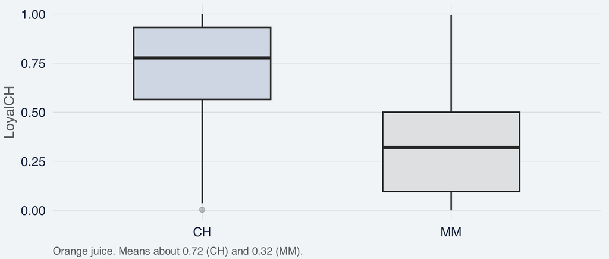

LoyalCH averages about 0.72 on CH visits and about 0.32 on MM visits.

## How does the CH share change across loyalty bins?

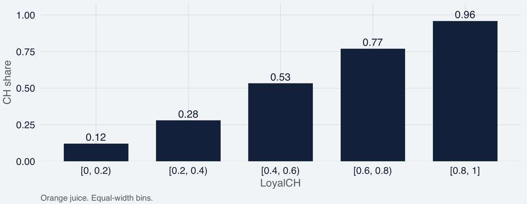

In the five bins, the share of visits that bought CH is about 0.12, 0.28, 0.53, 0.77, and 0.96.

## The linear probability model

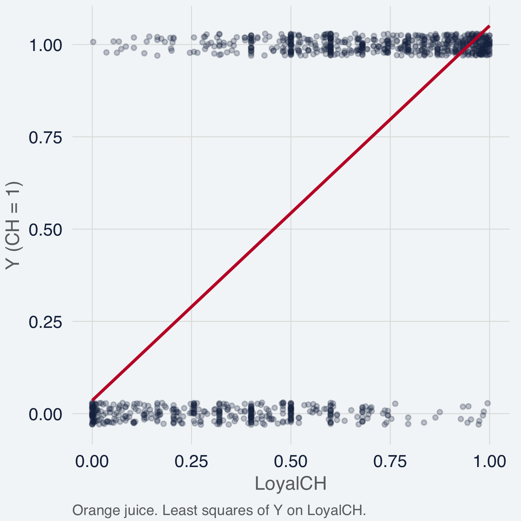

- Least squares of Y on LoyalCH:
  $$p(Y = 1 \mid \text{LoyalCH}) = b_0 + b_1\,\text{LoyalCH}$$
  $b_1$ is the change in the probability of CH when LoyalCH goes from 0 to 1.
- Suppose $b_1 = 0.8$. A customer whose LoyalCH is 0.1 higher has a probability of buying CH that is 0.08 higher, or 8 percentage points.
- For measuring effects, economists still use it. Because
  $$E(Y \mid X) = p(Y = 1 \mid X),$$
  $b_1$ is the effect of X on the probability. In a randomized job-training program, $b_1 = 0.05$ means training raises the probability of employment by 5 percentage points.
- For prediction, it is weak. Nothing keeps $b_0 + b_1 X$ between 0 and 1, so a predicted probability can be below 0 or above 1.

## What is wrong with the linear probability model?

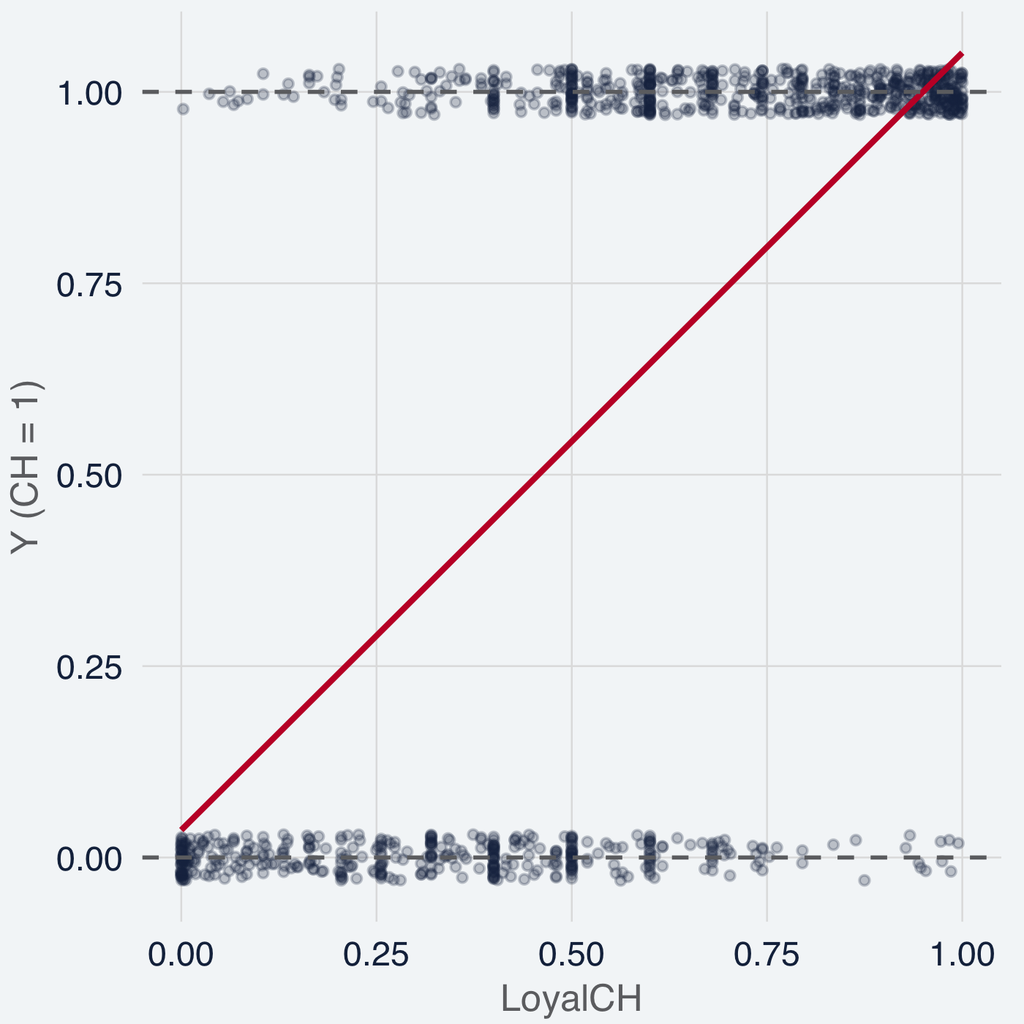

- **The errors are heteroskedastic.** The error variance is $p(1 - p)$, so it changes with LoyalCH. The usual standard errors are wrong; robust standard errors needed.
- **The errors are not normal.** Y is only 0 or 1, so at a given LoyalCH the error takes just two values, $1 - p$ or $-p$.
- **A predicted value can fall outside 0 and 1.** Nothing bounds the line. The dashed lines mark 0 and 1, and the line crosses 1 at high LoyalCH.

## How far outside 0 and 1 does the linear probability model go?

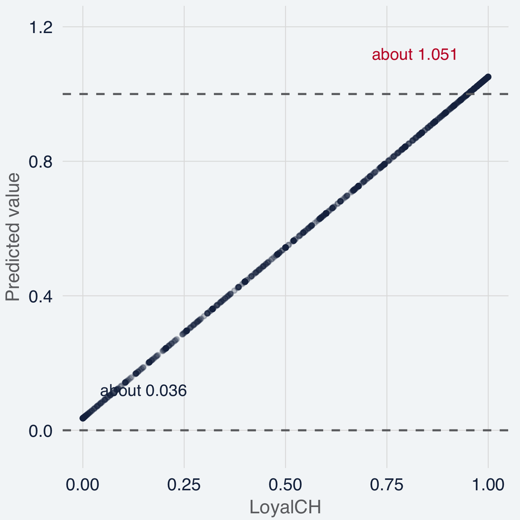

- The predicted values run from about 0.036 to 1.051. The line is

  $$0.036 + 1.015 \times \text{LoyalCH}.$$
- At loyalty 0 the calculation is

  $$0.036 + 1.015 \times 0 = 0.036.$$

  That value is still inside 0 and 1.
- At loyalty 1 the calculation is

  $$0.036 + 1.015 \times 1 = 1.051.$$

  That value is above 1, so it is not a probability of CH.
- Suppose the store uses these values to decide which shoppers get a Minute Maid coupon. Why could a predicted value of 1.051 be a problem?

## The linear probability model and logistic regression

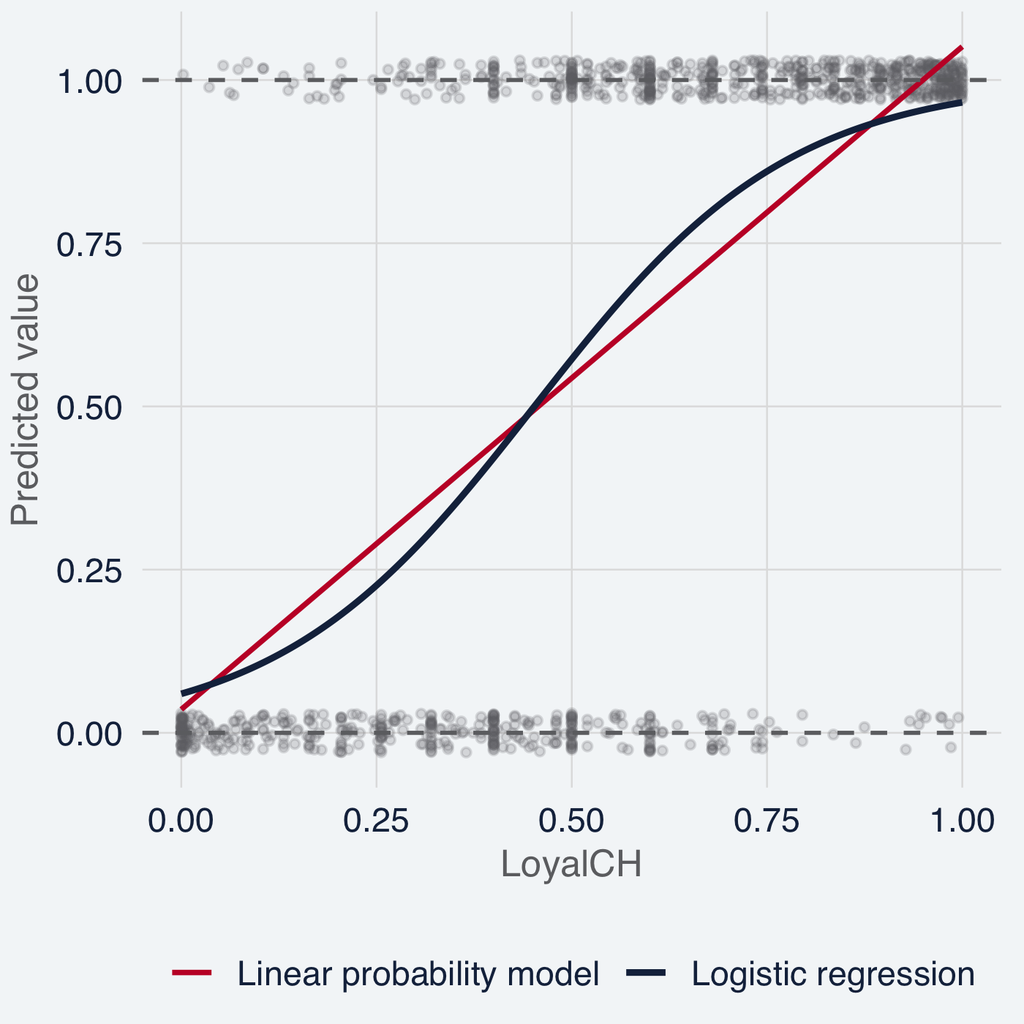

- The red line is least squares of Y on LoyalCH. Above 1, that fitted value is not a probability.
- The navy curve is logistic regression on the same loyalty. Every point on it is a probability of CH between 0 and 1.

## Logistic regression puts a line on the log-odds of CH

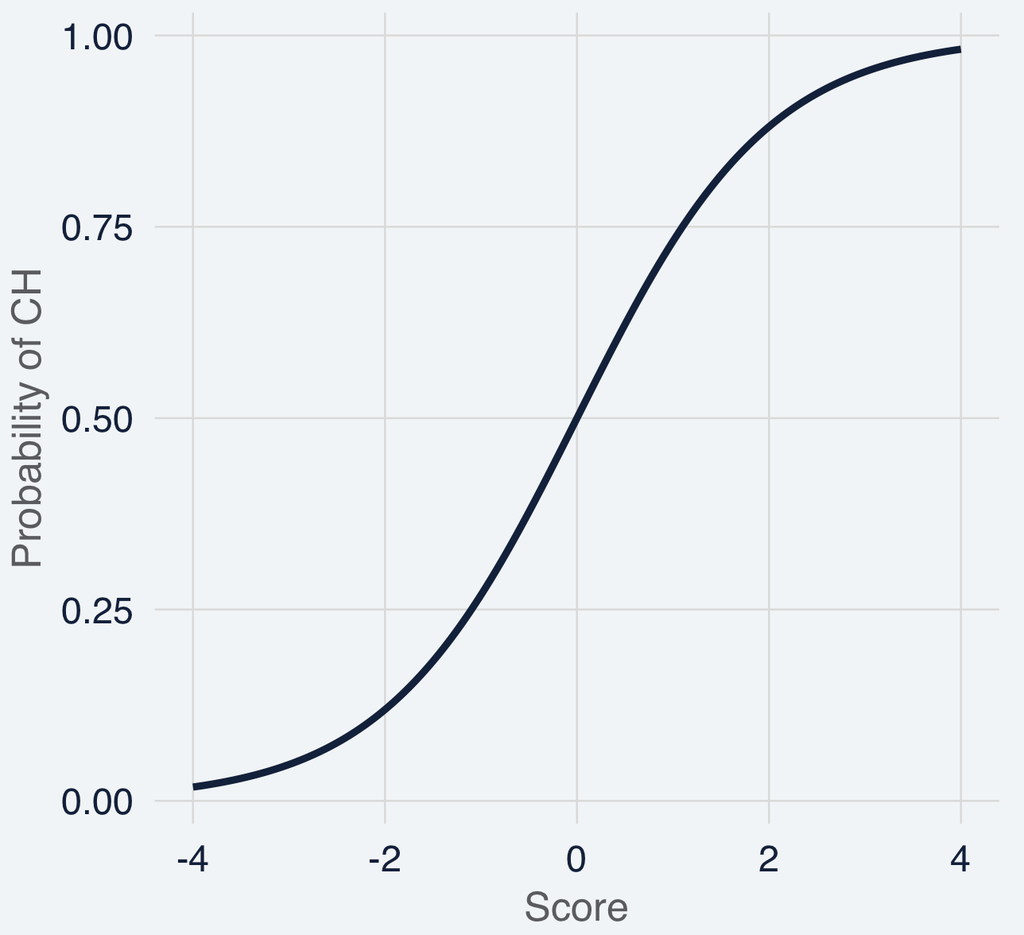

- The score is this line in LoyalCH. It is not yet a probability of CH:

  $$\text{score} = b_0 + b_1 \times \text{LoyalCH}.$$
- We do not fit Y. The curve turns the score into the probability of CH:

  $$p = \frac{e^{\text{score}}}{1 + e^{\text{score}}}.$$

  It stays between 0 and 1.
- The odds are the probability divided by one minus the probability. On this curve those odds equal $e$ to the score:

  $$\frac{p}{1-p} = e^{\text{score}}.$$
- Take the log of both sides. The score is that log-odds. With loyalty alone the LoyalCH coefficient is 6.09, so LoyalCH higher by 1 raises the log-odds of CH by 6.09:

  $$\log\left(\frac{p}{1-p}\right) = b_0 + 6.09 \times \text{LoyalCH}.$$

## What is the odds ratio of CH to MM?

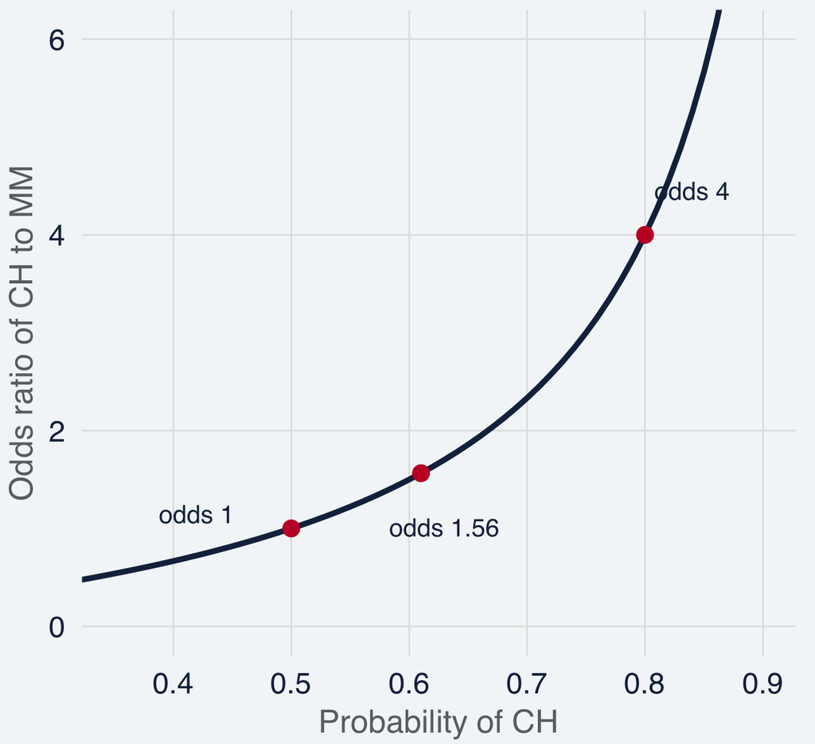

- The odds on the last slide are the odds ratio of CH to MM. That ratio is the probability of CH divided by the probability of MM:

  $$\frac{p}{1-p}.$$
- To go from the odds ratio back to the probability, divide the odds ratio by 1 plus the odds ratio:

  $$p = \frac{\text{odds ratio}}{1 + \text{odds ratio}}.$$
- An odds ratio of 1 gives a probability of 1/2. An odds ratio of 4 gives a probability of 0.8:

  $$\frac{1}{1+1} = \frac{1}{2}, \qquad \frac{4}{1+4} = 0.8.$$
- In this file the CH share is 0.61. The odds ratio is about 1.56, and that odds ratio comes back to a probability of about 0.61:

  $$\frac{0.61}{0.39} \approx 1.56, \qquad \frac{1.56}{1+1.56} \approx 0.61.$$

## How does logistic regression give the probability of CH from loyalty?

$$p(Y = 1 \mid \text{LoyalCH}) = \frac{e^{b_0 + b_1\,\text{LoyalCH}}}{1 + e^{b_0 + b_1\,\text{LoyalCH}}}$$

- `glm(Y ~ LoyalCH, family = binomial)` gives the estimated score:

  $$\text{score} = -2.76 + 6.09 \times \text{LoyalCH}.$$
- Put the score into the formula above. At loyalty 0 the score is −2.76:

  $$p = \frac{e^{-2.76}}{1 + e^{-2.76}} \approx 0.06.$$
- **The intercept.** A shopper with LoyalCH of 0 buys CH with a probability of about 0.06.
- **The coefficient in log-odds.** 6.09 is positive, so higher loyalty means a higher probability of CH. LoyalCH higher by 0.1 always raises the log-odds of CH by 6.09 × 0.1 ≈ 0.61.
- **The coefficient in probability.** The same 0.1 does not add a fixed amount to the probability. The next slide shows why.

## What does 0.1 more loyalty do to the probability of CH?

$$\text{score} = -2.76 + 6.09 \times \text{LoyalCH} \qquad p = \frac{e^{\text{score}}}{1 + e^{\text{score}}}$$

| Step | LoyalCH | Score | Probability of CH |
| --- | --- | --- | --- |
| A | 0.3 → 0.4 | −0.93 → −0.32 | 0.28 → 0.42 |
| B | 0.7 → 0.8 | 1.50 → 2.11 | 0.82 → 0.89 |

- The score rises by 6.09 × 0.1 ≈ 0.61 in both steps.
- The probability rises by 14 percentage points in step A (28% to 42%), but only 7 percentage points in step B (82% to 89%).
- In log-odds, 0.1 more loyalty always adds 0.61. In probability, the change depends on the shopper’s starting loyalty.

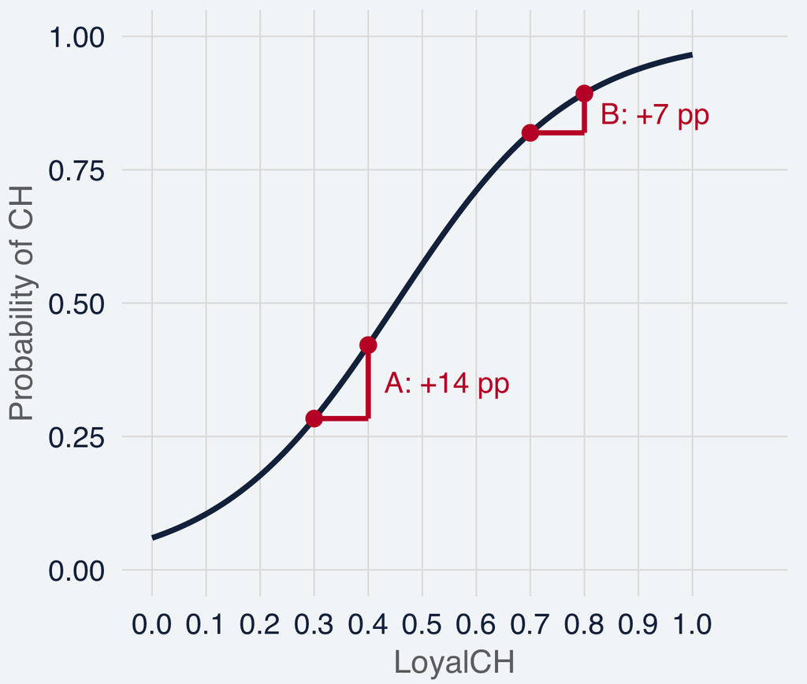

## What does 0.1 more loyalty do to the odds?

$$\text{odds} = \frac{p}{1-p} = e^{\text{score}} \qquad e^{0.61} \approx 1.84$$

| Step | LoyalCH | Score | Odds of CH | Probability of CH |
| --- | --- | --- | --- | --- |
| A | 0.3 → 0.4 | −0.93 → −0.32 | 0.39 → 0.73 | 0.28 → 0.42 |
| B | 0.7 → 0.8 | 1.50 → 2.11 | 4.48 → 8.25 | 0.82 → 0.89 |

- Both steps add 0.61 to the score, so both multiply the odds of CH by about 1.84, as in the box.
- A step of any size Δ in LoyalCH multiplies the odds by

  $$e^{6.09 \times \Delta}.$$
- The odds multiplier is the same for every shopper. The change in the probability is not.

## Why does step A move the probability more than step B?

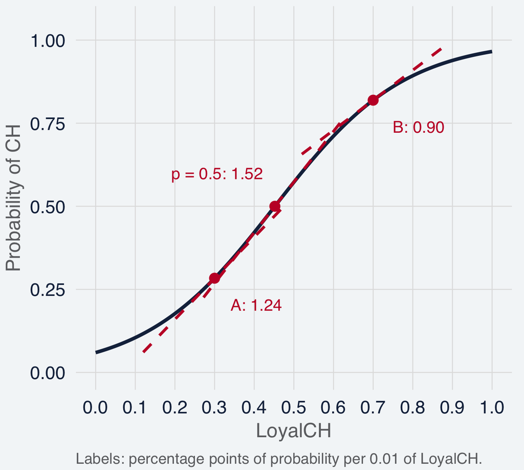

- The slope of the curve at a point with probability p is

  $$6.09 \times p \times (1-p).$$

  It is the change in the probability per unit of LoyalCH. Divide by 100 to read it per 0.01 of loyalty.
- At step A, p = 0.28 and the slope is about 1.24. Each extra 0.01 of loyalty raises the probability of CH by about 1.24 percentage points.
- At p = 0.5 the slope is largest, about 1.52, or 1.52 points per 0.01.
- At step B, p = 0.82 and the slope is about 0.90, or 0.90 points per 0.01. The same loyalty moves this shopper less.

## How do we read the LoyalCH coefficient of 6.09?

| Reading | Rule for a step Δ in LoyalCH | For 0.1 more loyalty | Same for every shopper? |
| --- | --- | --- | --- |
| Log-odds | add 6.09 × Δ | +0.61 | Yes |
| Odds | multiply by $e^{6.09 \times \Delta}$ | ×1.84 | Yes |
| Probability | compute p before and after | A: 0.28 → 0.42, +14 pp B: 0.82 → 0.89, +7 pp | No |

- Log-odds and odds give one number for everyone, but nobody thinks in log-odds or odds.
- The probability is what a manager needs, but it depends on where the shopper starts. Its slope, 6.09 × p × (1 − p), is called the **marginal effect** of LoyalCH.
- How to report it: “For a shopper at LoyalCH 0.3, 0.1 more loyalty raises the probability of CH by about 14 percentage points.”

## Does the price gap differ between CH visits and MM visits?

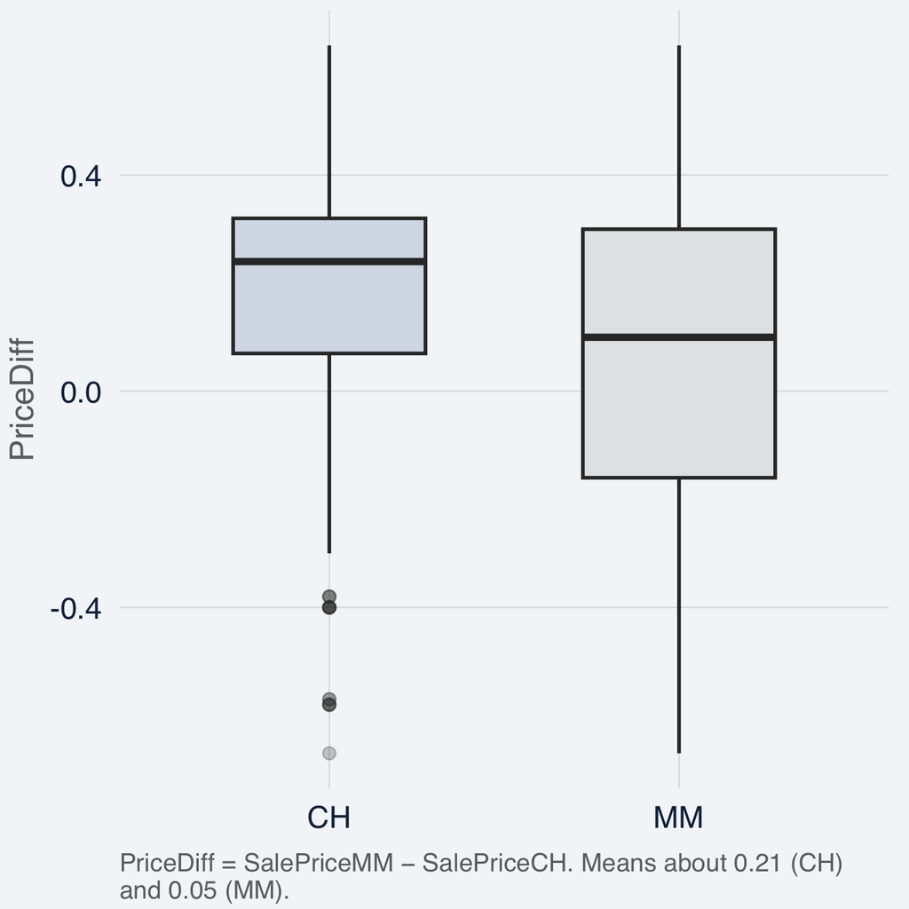

- PriceDiff is the MM price minus the CH price.
- It averages about 0.21 on CH visits and about 0.05 on MM visits.

## How do we fit both variables in R?

```r
fit2 <- glm(Y ~ LoyalCH + PriceDiff, data = oj, family = binomial)   # logistic regression: Y = 1 if CH
round(coef(fit2), 2)                                                 # intercept and the two slopes
round(exp(coef(fit2)[-1] * 0.1), 2)                                  # odds multiplier for +0.10 loyalty and +$0.10 gap
```

```
(Intercept)     LoyalCH   PriceDiff
      -3.25        6.40        2.86
  LoyalCH PriceDiff
     1.90      1.33
```

- **Score:** $\text{score} = -3.25 + 6.40 \times \text{LoyalCH} + 2.86 \times \text{PriceDiff}$.
- **Intercept, $-3.25$.** At $\text{LoyalCH} = 0$ and $\text{PriceDiff} = \$0.00$, the log-odds of CH are $-3.25$, the odds are $e^{-3.25} \approx 0.039$, and the probability of CH is $\frac{0.039}{1 + 0.039} \approx 0.04$ (4%).
- **LoyalCH, $6.40 > 0$ (0 to 1 scale).** Holding PriceDiff fixed, $+0.10$ in LoyalCH adds $6.40 \times 0.10 = 0.64$ to the log-odds of CH, multiplies the odds of CH by $e^{0.64} \approx 1.90$ ($+90\%$), and **increases $P(Y = 1)$**.
- **PriceDiff, $2.86 > 0$ (dollars: $\text{SalePriceMM} - \text{SalePriceCH}$).** Holding LoyalCH fixed, a $+\$0.10$ (10-cent) wider price gap adds $2.86 \times 0.10 \approx 0.29$ to the log-odds of CH, multiplies the odds of CH by $e^{0.286} \approx 1.33$ ($+33\%$), and **increases $P(Y = 1)$**.

## What is the marginal effect for one shopper?

$$\text{marginal effect of } x_j = b_j \times p \times (1-p)$$

```r
shopper <- data.frame(LoyalCH = 0.5, PriceDiff = 0)        # the shopper we pick: medium loyalty, equal prices
p0 <- unname(predict(fit2, shopper, type = "response"))   # P(CH) for this shopper
round(c(p = p0,                                            # print p ...
        coef(fit2)[-1] * p0 * (1 - p0)), 2)                # ... then b x p x (1 - p) for each variable
```

```
        p   LoyalCH PriceDiff
     0.49      1.60      0.72
```

| Variable | $b_j$ | $p(1-p)$ | Marginal effect (per 1 unit) | Per realistic step |
| --- | --- | --- | --- | --- |
| LoyalCH | 6.40 | 0.49 × 0.51 ≈ 0.25 | 6.40 × 0.25 ≈ 1.60 | +0.10 loyalty: **+16 pp** |
| PriceDiff | 2.86 | 0.25 | 2.86 × 0.25 ≈ 0.72 | +$0.10 gap: **+7.2 pp** |

- **Our shopper:** LoyalCH 0.5, equal prices, $p = 0.49$.
- **LoyalCH:** 0.10 more loyalty raises her probability of CH by about **16 percentage points**.
- **PriceDiff:** MM costing $0.10 more raises it by about **7.2 percentage points**.

## What is the average marginal effect (AME) across all shoppers?

$$\text{AME of } x_j = \frac{1}{n}\sum_{i=1}^{n} b_j \times p_i \times (1-p_i) = \text{average of the } n = 1{,}070 \text{ marginal effects, each at its own } p_i$$

```r
p        <- predict(fit2, type = "response")        # P(CH) for each of the 1,070 visits
me_loyal <- coef(fit2)["LoyalCH"]   * p * (1 - p)   # marginal effect of LoyalCH, one per visit
me_gap   <- coef(fit2)["PriceDiff"] * p * (1 - p)   # marginal effect of PriceDiff, one per visit
round(c(LoyalCH = mean(me_loyal), PriceDiff = mean(me_gap)), 3)   # AME = average of each
```

```
  LoyalCH PriceDiff
    0.795     0.356
```

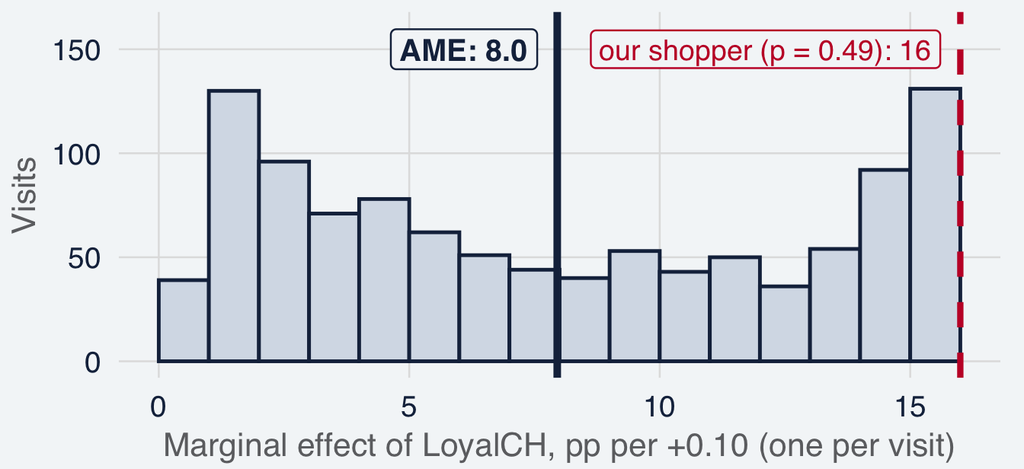

- **LoyalCH:** 0.795 × 0.10 ≈ **+8.0 pp** per +0.10 loyalty.
- **PriceDiff:** 0.356 × 0.10 ≈ **+3.6 pp** per +$0.10 gap.
- **Why 8.0, not last slide’s 16:** our shopper was undecided, close to 50/50. Many shoppers are almost sure to buy CH or MM, so more loyalty barely moves them. That lowers the average.

**Your turn:** when would you report the marginal effect for one shopper, and when the AME?

## When do we use the marginal effect and when the AME?

It depends on who the decision is for. Take the Citrus Hill brand manager with a 10-cent price cut, which raises PriceDiff by $0.10.

Marginal effect: one customer or segment

- **Question:** who should get a 10-cent CH coupon?
- **Undecided shopper** (LoyalCH 0.5, $p = 0.49$): **+7.2 pp**.
- **Loyal shopper** (LoyalCH 0.9, $p = 0.92$): **+2.0 pp**. She buys CH anyway.
- **Decision:** send coupons to undecided shoppers, not loyal ones.

AME: a policy for everyone

- **Question:** what does a 10-cent CH price cut in every store do?
- **Every visit** gets the cut, so average over all 1,070: **+3.6 pp**.
- **In sales:** $0.036 \times 1{,}070 \approx 38$ more CH purchases per 1,070 visits.
- **Decision:** compare those 38 extra sales with the cost of 10 cents on every CH sale.

Deciding for one customer or segment: marginal effect at their $p$. Deciding for everyone at once: the AME.

## Can we rank the variables by the size of their coefficients?

No. Each coefficient is the change in log-odds for **one unit** of its variable, and the units differ.

```r
sds <- sapply(oj[, c("LoyalCH", "PriceDiff")], sd)   # standard deviation: a typical move in each variable
round(sds, 2)
```

```
  LoyalCH PriceDiff
     0.31      0.27
```

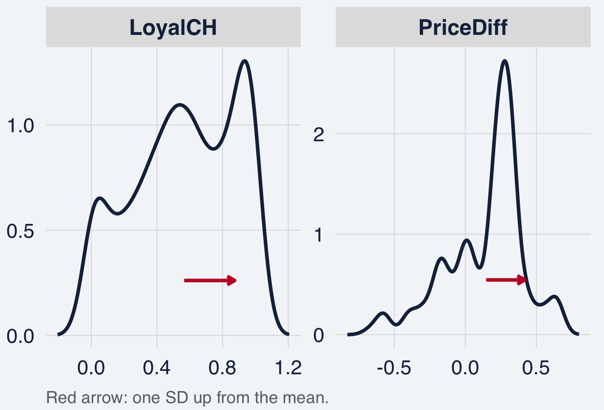

- **Importance needs two numbers:** the coefficient (effect per unit) and how much the variable actually varies across visits (its SD).
- **LoyalCH:** $b = 6.40$ per unit, but one unit is the whole 0-to-1 scale. Shoppers typically differ by **0.31**.
- **PriceDiff:** $b = 2.86$ per $1, but the gap only runs from −$0.67 to +$0.64. Visits typically differ by **$0.27**.
- **Why both:** a big coefficient on a variable that barely moves matters little. In cents, the gap’s $b$ is 0.0286 and its SD is 27, so $b \times \text{SD}$ does not change.

## How do we compare the variables on one scale?

$$\text{log-odds change for +1 SD} = b_j \times \text{SD}_j \qquad\quad \text{odds multiplier for +1 SD} = e^{\,b_j \times \text{SD}_j}$$

```r
b   <- coef(fit2)[-1]                           # slopes: change in log-odds per 1 unit
std <- b * sds                                  # change in log-odds per 1 SD (standardized coefficient)
round(rbind(b, sds, std, odds = exp(std)), 2)   # last row: odds multiplier per 1 SD
```

```
     LoyalCH PriceDiff
b       6.40      2.86
sds     0.31      0.27
std     1.97      0.78
odds    7.16      2.18
```

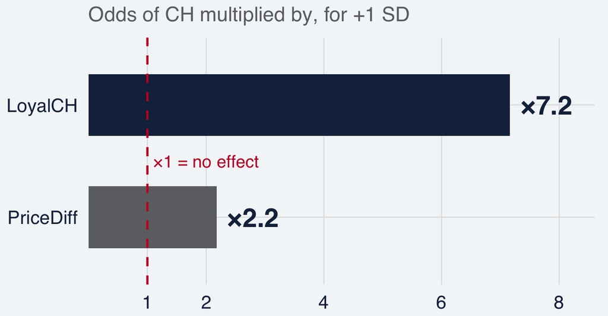

- **LoyalCH:** $6.40 \times 0.31 = 1.97$ in log-odds, so **+0.31 loyalty multiplies the odds of CH by $e^{1.97} \approx 7.2$**.
- **PriceDiff:** $2.86 \times 0.27 = 0.78$ in log-odds, so **a $0.27 wider gap multiplies them by $e^{0.78} \approx 2.2$**.
- **Ranking:** a typical move in loyalty matters more than a typical move in price.

## Does the ranking hold for the probability and for the fit?

```r
ame <- c(LoyalCH = mean(me_loyal), PriceDiff = mean(me_gap))   # AMEs from the AME slide
round(100 * ame * sds, 1)                                       # pp change in P(CH) for +1 SD
drop1(fit2, test = "LRT")[-1, c("Deviance", "LRT")]             # refit without each variable: how much worse?
```

```
  LoyalCH PriceDiff
     24.5       9.7
          Deviance    LRT
LoyalCH    1348.84 508.49
PriceDiff   920.57  80.22
```

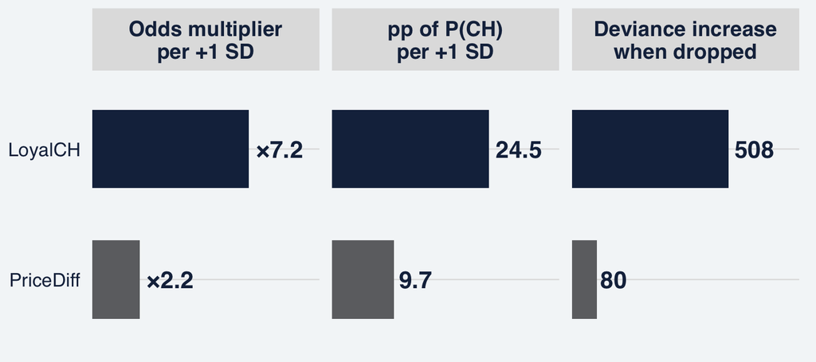

- **Probability (AME × SD):** +1 SD raises P(CH) on average by **24.5 pp** for loyalty, **9.7 pp** for the gap.
- **Fit:** deviance measures misfit (lower is better). Dropping loyalty raises it by **508**, dropping the gap by **80**. Both increases have p < 0.001.

All three agree: loyalty first, price gap second, and both stay in the model.

## How do we score a new visit?

$$\text{score} = -3.25 + 6.40 \times 0.5 + 2.86 \times 0.2 = 0.522 \qquad\quad p = \frac{e^{0.522}}{1 + e^{0.522}} \approx 0.63$$

```r
visit <- data.frame(LoyalCH = 0.5, PriceDiff = 0.2)   # a new visit: medium loyalty, MM costs $0.20 more
round(predict(fit2, visit, type = "response"), 2)     # R's probability of CH for this visit
```

```
   1
0.63
```

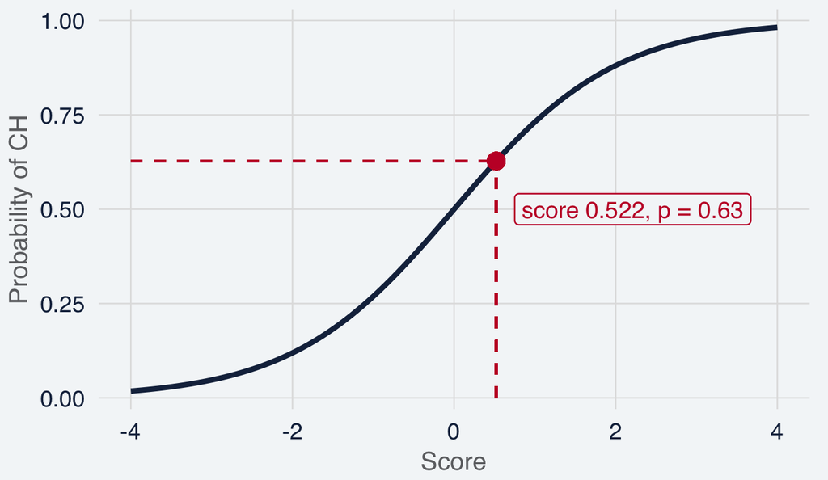

- **The model is a scoring rule:** plug in any visit’s LoyalCH and PriceDiff, add up the score, then turn the score into a probability.
- **By hand:** score 0.522, probability of CH about **0.63**.
- **In R:** `predict(..., type = "response")` returns the same **0.63**.

## Does a higher score always mean a higher probability?

```r
ranked <- data.frame(LoyalCH = round(oj$LoyalCH, 2), PriceDiff = oj$PriceDiff,
                     score = round(predict(fit2), 2),                     # score (log-odds) for every visit
                     p_CH  = round(predict(fit2, type = "response"), 2),  # probability of CH for every visit
                     bought = oj$Purchase)
ranked <- ranked[order(-ranked$score), ]                                  # sort: highest score first
rbind(head(ranked, 3), tail(ranked, 3))                                   # top 3 and bottom 3 of 1,070 visits
```

```
    LoyalCH PriceDiff score p_CH bought
200    1.00      0.64  4.98 0.99     CH
192    1.00      0.64  4.97 0.99     CH
610    0.99      0.64  4.94 0.99     CH
726    0.00     -0.40 -4.40 0.01     MM
798    0.03     -0.57 -4.66 0.01     MM
295    0.00     -0.58 -4.91 0.01     MM
```

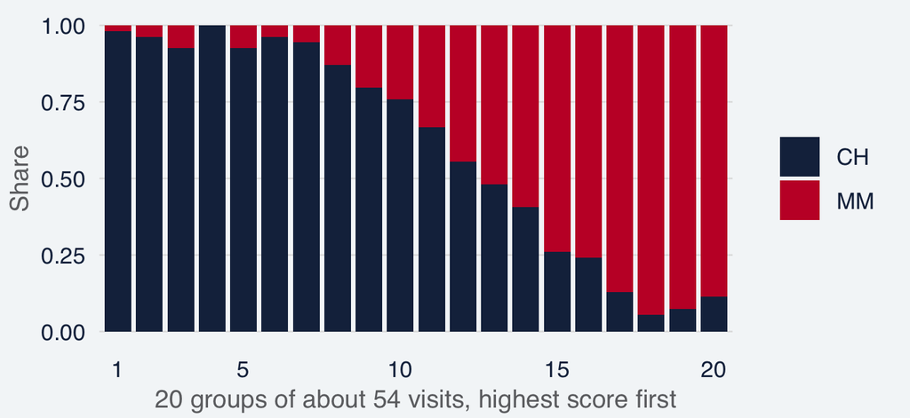

- **Same order:** a higher score always gives a higher probability, so sorting by score is sorting by probability.
- **The ends are easy:** the top visits ($p \approx 0.99$) bought CH; the bottom ones ($p \approx 0.01$) bought MM.
- **The middle is mixed:** to classify each visit as CH or MM we need a threshold. How often will we be wrong?

## Should we add more price variables?

```r
round(cor(oj$LoyalCH, oj$PriceDiff), 2)                          # loyalty vs price gap
round(cor(oj$PriceDiff, oj[, c("SalePriceMM", "DiscMM")]), 2)    # price gap vs two other price columns
fit_all <- glm(Y ~ LoyalCH + PriceDiff + SalePriceMM + SalePriceCH, data = oj, family = binomial)
round(coef(fit_all), 2)                                          # add two more price columns
```

```
[1] 0.1
     SalePriceMM DiscMM
[1,]        0.85  -0.82
(Intercept)     LoyalCH   PriceDiff SalePriceMM SalePriceCH
      -1.45        6.43        3.71       -0.99          NA
```

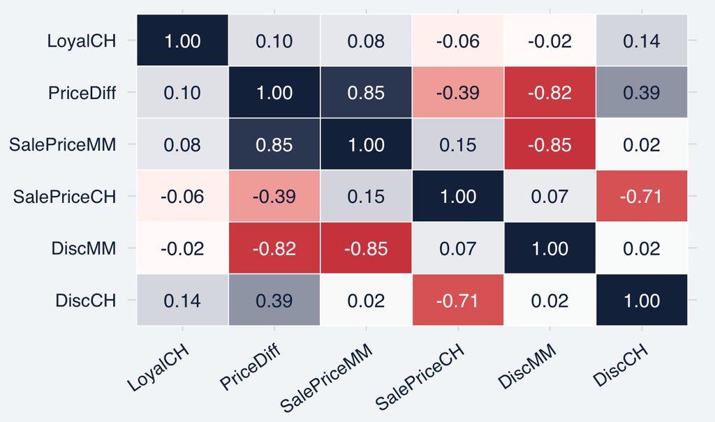

- **LoyalCH and PriceDiff:** correlation **0.10**. Each brings its own information, so keep both.
- **PriceDiff and other price columns:** **0.85** with SalePriceMM, **−0.82** with DiscMM. Near copies of the same information.
- **Add them anyway:** R returns **NA** for SalePriceCH, because PriceDiff is exactly SalePriceMM − SalePriceCH. PriceDiff jumps from 2.86 to 3.71, and those coefficients are no longer separate price effects.
- **Rule:** keep a small set of variables that are not copies of each other (Session 4: selection and regularization).

## Checklist: is our logistic regression ready?

- ✓ **Linear in the log-odds:** $\text{log-odds of CH} = -3.25 + 6.40 \times \text{LoyalCH} + 2.86 \times \text{PriceDiff}$.
- ✓ **Variable selection:** two variables with correlation 0.10. Price columns that copy PriceDiff are left out.
- ✓ **Scoring:** loyalty 0.5 and a gap of +$0.20 give a score of 0.522 and a probability of 0.63. Sorting by score is sorting by probability.
- ✓ **Coefficients:** +0.10 loyalty adds 0.64 to the log-odds and multiplies the odds by 1.90 (+90%). In probability it depends on the shopper: +16 pp at $p = 0.49$, +8.0 pp on average (AME).
- ✓ **Variable importance:** how far $e^{b \times \text{SD}}$ is from 1. Loyalty about ×7.2 (+616% odds), gap about ×2.2 (+118%), both $p < 0.001$. Loyalty first.

**Still open, accuracy:** how often is the predicted brand correct?

## Assessing the classification accuracy

Every visit now has a probability of CH. A store needs a prediction: CH or MM. So the last question of the session is: what is the measure of accuracy for a classification model?

Step 1

The confusion matrix

What can a prediction get right or wrong?

Four outcomes, four rates

Step 2

The threshold

When do we predict CH instead of MM?

Thresholds 0.5 and 0.8

Step 3

Count the errors

How accurate is the model at 0.5 and at 0.8?

Accuracy, sensitivity, specificity, precision

Step 4

All thresholds at once

How well does the model rank visits? Who gets a coupon?

ROC curve, AUC, lift

Step 5

New visits

Do the numbers hold on visits the model has not seen?

70/30 test split

Steps 1 to 4 use the 1,070 visits. Step 5 uses 321 visits held out from fitting.

## What is a confusion matrix?

A classification model predicts a class for each case. The confusion matrix crosses the **predicted** class with the **actual** class. The **positive** class is the one we want to find; here it is CH ($Y = 1$).

Actual class

Predicted class

Positive (CH)

Negative (MM)

Positive (CH)

Negative (MM)

TPTrue positive

FPFalse positiveType I error

FNFalse negativeType II error

TNTrue negative

Navy: correct predictions. Red: errors.

Accuracy

$$\frac{TP + TN}{TP + FP + FN + TN}$$

Share of **all** predictions that are correct.

Precision

$$\frac{TP}{TP + FP}$$

Of the cases **predicted positive**, the share that are actually positive.

Sensitivity (recall)

$$\frac{TP}{TP + FN}$$

Of the **actual positives**, the share predicted positive.

Specificity

$$\frac{TN}{TN + FP}$$

Of the **actual negatives**, the share predicted negative. One minus specificity is the false-positive rate (FPR).

**Each rate divides by a different group.** Before you read a rate, ask: a share of which cases?

## How do we turn a probability into a predicted brand?

$$\text{predict CH if } p > c \iff \text{score} > \ln\frac{c}{1-c} \qquad c = 0.5:\ \text{score} > 0 \qquad c = 0.8:\ \text{score} > \ln 4$$

```r
pred_05 <- oj$p_hat > 0.5                  # TRUE = predict CH, FALSE = predict MM (threshold 0.5)
pred_08 <- oj$p_hat > 0.8                  # a stricter threshold: predict CH only when p > 0.8
c(threshold_0.5 = sum(pred_05), threshold_0.8 = sum(pred_08))   # visits predicted CH at each threshold
```

```
threshold_0.5 threshold_0.8
          668           460
```

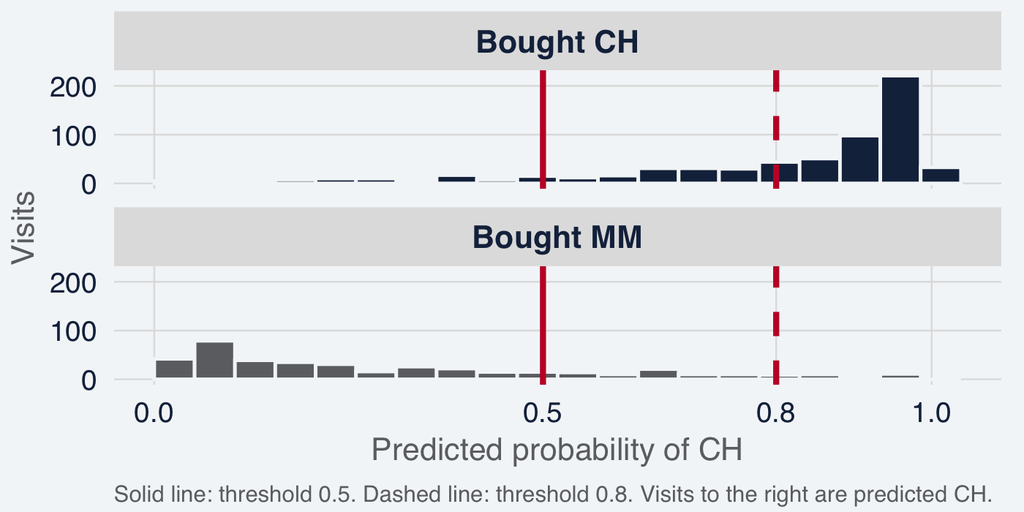

- **Threshold 0.5:** $p = 0.5$ is odds of 1 and a score of 0, so “score above 0” is the 0.5 rule. **668** of the 1,070 visits are predicted CH.
- **Threshold 0.8:** $p = 0.8$ is odds of $0.8/0.2 = 4$, so the score must be above $\ln 4$. Only **460** visits are predicted CH.
- **Where the errors are:** the two brands overlap in the middle. A CH buyer left of the threshold is predicted MM. An MM buyer right of the threshold is predicted CH.

## What goes in the confusion matrix?

```r
predicted <- ifelse(pred_05, "CH", "MM")    # predicted brand at the 0.5 threshold
bought    <- oj$Purchase                    # the brand the shopper actually bought
table(predicted, bought)                    # rows: predicted brand; columns: brand bought
```

```
         bought
predicted  CH  MM
       CH 570  98
       MM  83 319
```

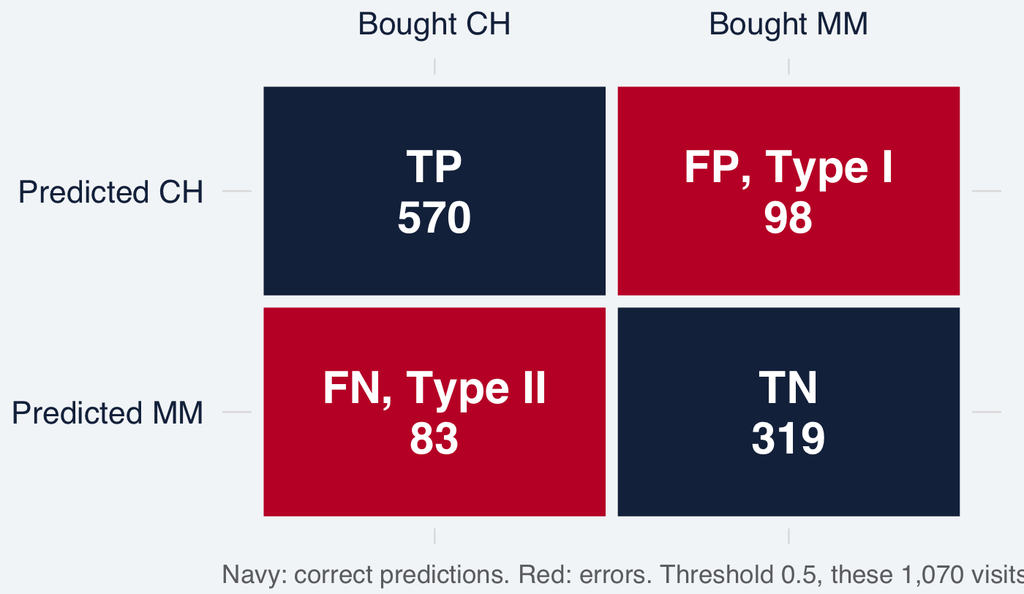

- **CH is the positive class** ($Y = 1$).
- **True positive (TP), 570:** predicted CH and bought CH.
- **False positive (FP), 98:** predicted CH but bought MM. A **Type I** error.
- **False negative (FN), 83:** predicted MM but bought CH. A **Type II** error.
- **True negative (TN), 319:** predicted MM and bought MM.

## How accurate is the model at a threshold of 0.5?

$$\text{accuracy} = \frac{TP + TN}{TP + FP + FN + TN} = \frac{570 + 319}{1{,}070} = 0.831$$

```r
correct <- pred_05 == (oj$Y == 1)        # TRUE when the prediction matches the brand bought
round(c(model  = mean(correct),          # accuracy at the 0.5 threshold
        all_CH = mean(oj$Y == 1)), 3)    # accuracy of predicting CH for every visit
```

```
 model all_CH
 0.831  0.610
```

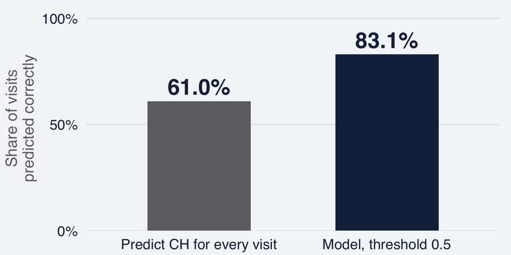

- **Model:** correct on **889** of the 1,070 visits, **83.1%**.
- **Benchmark:** predicting CH for every visit is correct **61.0%** of the time, because 653 of the 1,070 visits bought CH. It never identifies an MM buyer.
- **Caution:** accuracy looks high whenever one class is common. If only 5% of visits bought MM, predicting CH for every visit is 95% accurate and finds no MM buyer. Always compare with this benchmark.

## Which errors does the model make at a threshold of 0.5?

$$\text{sensitivity} = \frac{TP}{TP + FN} \qquad \text{specificity} = \frac{TN}{TN + FP} \qquad \text{precision} = \frac{TP}{TP + FP} \qquad \text{FPR} = \frac{FP}{FP + TN}$$

```r
tp <- sum(pred_05 & oj$Y == 1); fn <- sum(!pred_05 & oj$Y == 1)   # CH buyers: predicted CH, predicted MM
tn <- sum(!pred_05 & oj$Y == 0); fp <- sum(pred_05 & oj$Y == 0)   # MM buyers: predicted MM, predicted CH
round(c(sensitivity = tp / (tp + fn), specificity = tn / (tn + fp),   # share of each brand predicted correctly
        precision = tp / (tp + fp), fpr = fp / (fp + tn)), 3)         # correct CH predictions; MM buyers predicted CH
```

```
sensitivity specificity   precision         fpr
      0.873       0.765       0.853       0.235
```

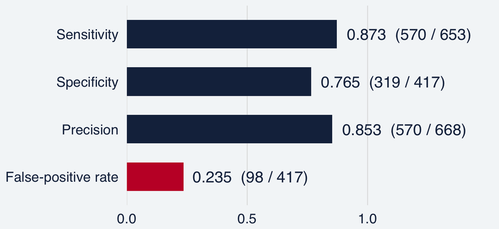

- **Sensitivity 0.873:** of the 653 CH buyers, 570 are predicted CH. Also called **recall**.
- **Specificity 0.765:** of the 417 MM buyers, 319 are predicted MM.
- **Precision 0.853:** of the 668 visits predicted CH, 570 bought CH.
- **False-positive rate (FPR) 0.235:** of the 417 MM buyers, 98 are predicted CH. It is 1 − specificity, and the ROC curve uses it.
- **Recall vs precision:** recall asks how many CH buyers we found. Precision asks how many of our CH predictions were correct.

## What happens if we raise the threshold to 0.8?

```r
rates <- function(threshold) {                    # the rates for any threshold
  pred_ch <- oj$p_hat > threshold                 # predict CH above the threshold
  c(sensitivity = mean(pred_ch[oj$Y == 1]),       # share of CH buyers predicted CH
    specificity = mean(!pred_ch[oj$Y == 0]),      # share of MM buyers predicted MM
    precision   = mean(oj$Y[pred_ch] == 1),       # share of CH predictions that bought CH
    accuracy    = mean(pred_ch == (oj$Y == 1)))   # share of all predictions that are correct
}
round(rbind(threshold_0.5 = rates(0.5), threshold_0.8 = rates(0.8)), 3)   # the two thresholds side by side
```

```
              sensitivity specificity precision accuracy
threshold_0.5       0.873       0.765     0.853    0.831
threshold_0.8       0.662       0.933     0.939    0.767
```

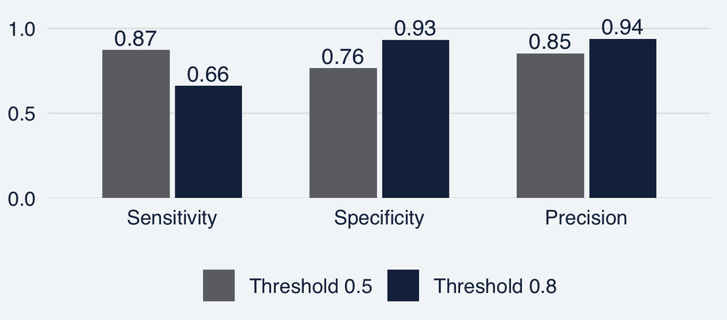

- **Fewer false CH predictions:** MM buyers predicted CH fall from 98 to **28**. Specificity rises to **0.933**, precision to **0.939**.
- **More missed CH buyers:** CH buyers predicted MM rise from 83 to **221**. Sensitivity falls to **0.662**.
- **Accuracy falls** from 0.831 to **0.767**, but accuracy counts both errors as equally costly.

**Your turn:** which threshold should Citrus Hill use?

## How does the ROC curve show every threshold at once?

The answer depends on what each error costs. Before choosing, look at every threshold at once.

```r
thresholds <- seq(0, 1, by = 0.01)                                                     # 101 thresholds from 0 to 1
roc <- data.frame(fpr = sapply(thresholds, function(k) mean(oj$p_hat[oj$Y == 0] > k)), # MM buyers predicted CH
                  tpr = sapply(thresholds, function(k) mean(oj$p_hat[oj$Y == 1] > k))) # CH buyers predicted CH
```

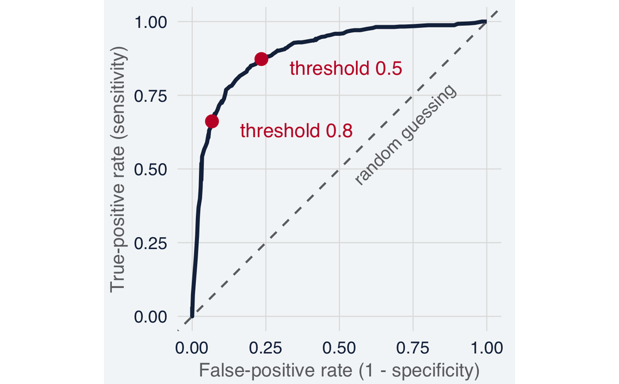

- **Each threshold is one point:** false-positive rate $\frac{FP}{FP+TN}$ on the x-axis, true-positive rate $\frac{TP}{TP+FN}$ on the y-axis. Threshold 0.5 is (0.235, 0.873); threshold 0.8 is (0.067, 0.662).
- **Lowering the threshold** predicts CH for more visits, so both rates rise, up to (1, 1) at a threshold of 0.
- **The diagonal** is random guessing. A useful model’s curve bends toward the top left: most CH buyers found, few MM buyers predicted CH.
- Choosing the point depends on what each error costs, business judgement.
- **Your turn:** Citrus Hill sends a loyalty coupon to every visit predicted CH. Which costs more, a coupon wasted on an MM buyer or a CH buyer we miss? Where on the curve should we be?